# Report

## Task A

I am training a XGBoost model (so a tree ensemble model) on the **yeast_me2** dataset. Unfortunately, I could not find readable descriptions of features in this dataset so they are just numbered. I first used the `dalex` package and then the `shap` package.

I have found two observations that have different most important features (the following plot is from dalex package):

[figure not shown]

here are the results from the shap package:

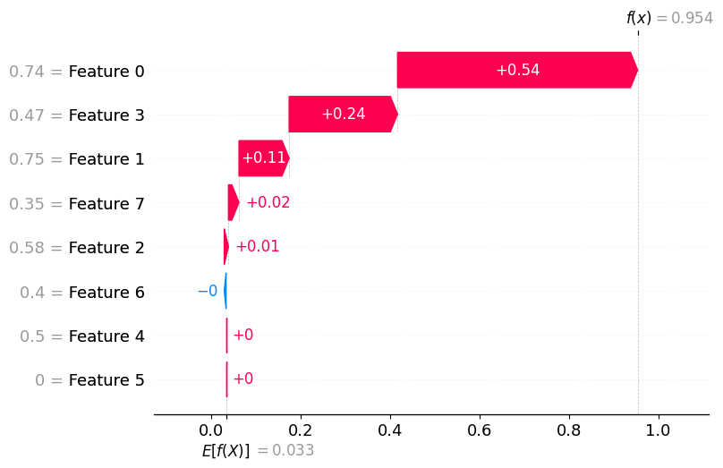

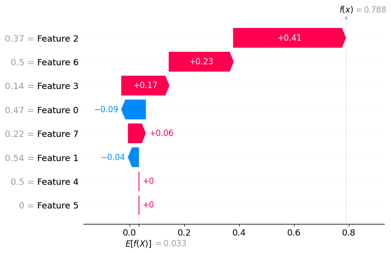

```python
for i in observation_to_explain_indices:
    shap.plots.waterfall(shap_values[i])
```

Task 4

In both methods the 3 most important features for observation 46 are features 3, 0 and 1, while for observation 221 they are features 2, 6 and 3.

Task 5

This two observations are also an example for the phenomenon, where the same feature, namely feature 1, has positive attribution for one, while it has a negative attribution for another.

Task 6

As we can see, the methods from different packages are similar, yet they are not the same. This may be caused by the fact that they are just approximations based on random samples.

Task 7

I wanted to generate SHAP explanations for the TabPFN model used in HW1, however it was very time consuming, so instead I trained an SVM model and looked at its explanations for the same observations using `dalex` package. They do share some of the most important features, however differ in most of the case. Moreover, we can see that the SVM model has lower predictions, so is less 'sure' which can partly explain those explanations being different.

[figure not shown]

## Task B

```
v() = 0
v(A) = 20
v(B) = 20
v(C) = 60
v(A,B) = 60
v(A,C) = 70
v(B,C) = 70
v(A,B,C) = 100
```

Let's consider permutations in the following order: ABC, ACB, BAC, BCA, CAB, CBA.

$$ \phi_A(v) = \frac{1}{6} \big( v(A) - v() + v(A) - v() + v(A, B) - v(B) + v(A, B, C) - v(B,C) + v(A, C) - v(C) + v(A, B, C) - v(B, C) \big) = \frac{1}{6} (20 + 20 + 40 + 30 + 10 + 30) = 25$$

$$ \phi_B(v) = \frac{1}{6} \big( v(A, B) - v(A) + v(A, B, C) - v(A, C) + v(B) - v() + v(B) - v() + v(A, B, C) - v(A, C) + v(B, C) - v(C) \big) = \frac{1}{6} (40 + 30 + 20 + 20 + 30 + 10) = 25$$

$$ \phi_C(v) = \frac{1}{6} \big( v(A, B, C) - v(A, B) + v(A, C) - v(A) + v(A, B, C) - v(A, B) + v(B, C) - v(B) + v(C) - v() + v(C) - v() \big) = \frac{1}{6} (40 + 50 + 40 + 50 + 60 + 60) = 50$$

# Appendix

## Imports and data loading

```python
import warnings
warnings.filterwarnings("ignore")
```

```python
import numpy as np
import pandas as pd
```

```python
!pip install -U imbalanced-learn
!pip install xgboost
!pip install dalex
!pip install shap
```

```python
from imblearn.datasets import fetch_datasets

imblearn_datasets = fetch_datasets()
```

```python
from collections import Counter

yeast_me2 = imblearn_datasets['yeast_me2']
print("dataset shape: ", yeast_me2.data.shape)
smaller, bigger = list(sorted(Counter(yeast_me2.target).values()))
print(f"{bigger=}, {smaller=}, imbalance ratio={bigger/smaller:.2f}")
```

```python
from sklearn.model_selection import train_test_split
from imblearn.over_sampling import SMOTE

X, y = yeast_me2.data, yeast_me2.target
y[y == -1] = 0

X_train, X_test, y_train, y_test = train_test_split(X, y, test_size=0.33, random_state=42)

X_resampled, y_resampled = SMOTE().fit_resample(X_train, y_train)
```

```python
from sklearn.metrics import accuracy_score, confusion_matrix, f1_score, roc_auc_score, recall_score, precision_score

def evaluate_method(method_name, y_test, y_eval, verbose=False):
    results = {
        func.__name__: func(y_test, y_eval) for func in [
            accuracy_score,
            confusion_matrix,
            f1_score,
            roc_auc_score,
            recall_score,
            precision_score
        ]
    }

    if verbose:
        print(method_name, ' results:')
        for func_name, score in results.items():
            print("\t", func_name, ": ", score)

    return results
```

## Gradient boosting

```python
from xgboost import XGBClassifier

# With SMOTE.
XGBoost_model_smote = XGBClassifier().fit(X_resampled, y_resampled)
y_eval_XGBoost_smote = XGBoost_model_smote.predict(X_test)
results_XGBoost_smote = evaluate_method('XGBoost with SMOTE', y_test, y_eval_XGBoost_smote)
```

## SHAP for XGBoost

```python
observation_to_explain_indices = [46, 221]
```

### `dalex` package

```python
import dalex as dx
import xgboost
import shap
```

```python
pf_xgboost_classifier_default = lambda m, d: m.predict_proba(d)[:, 1]

explainer = dx.Explainer(XGBoost_model_smote, X_test, y_test, predict_function=pf_xgboost_classifier_default, label="GBM")
```

```
Preparation of a new explainer is initiated

  -> data              : numpy.ndarray converted to pandas.DataFrame. Columns are set as string numbers.
  -> data              : 490 rows 8 cols
  -> target variable   : 490 values
  -> model_class       : xgboost.sklearn.XGBClassifier (default)
  -> label             : GBM
  -> predict function  : <function <lambda> at 0x7c93cb77be20> will be used
  -> predict function  : Accepts pandas.DataFrame and numpy.ndarray.
  -> predicted values  : min = 6.44e-06, mean = 0.0568, max = 1.0
  -> model type        : classification will be used (default)
  -> residual function : difference between y and yhat (default)
  -> residuals         : min = -1.0, mean = -0.0323, max = 0.999
  -> model_info        : package xgboost

A new explainer has been created!
```

```python
predictions = explainer.predict(X[observation_to_explain_indices, :])
shap_attributions = [explainer.predict_parts(X[i, :], type="shap", label=f'observation {i}, prediction: {predictions[idx]:.2f}') for idx, i in enumerate(observation_to_explain_indices)]
shap_attributions[0].plot(shap_attributions[1::])
```

[interactive chart not shown]

```python
bd_attributions = [explainer.predict_parts(X[i, :], type="break_down", label=f'observation {i}, prediction: {predictions[idx]:.2f}') for idx, i in enumerate(observation_to_explain_indices)]
bd_attributions[0].plot(bd_attributions[1::])
```

[interactive chart not shown]

### `shap` package

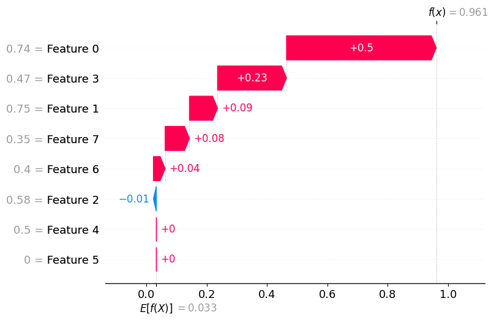

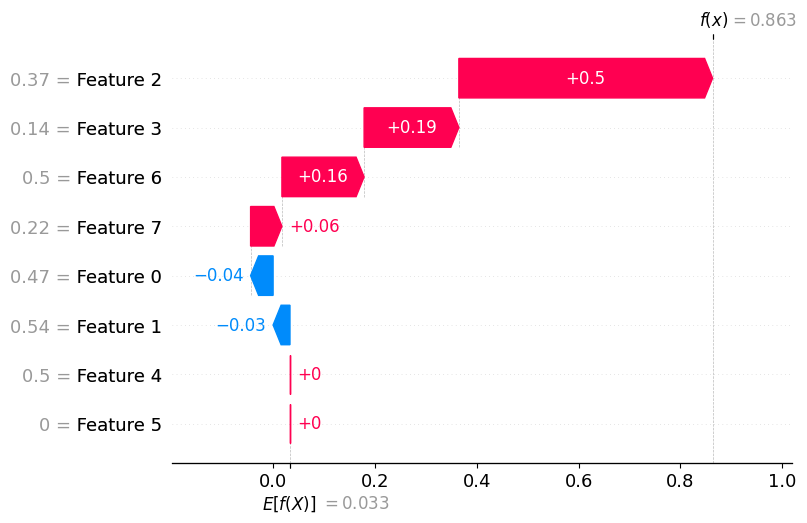

```python
shap_explainer = shap.explainers.Tree(XGBoost_model_smote, data=X, model_output="probability")
shap_values = shap_explainer(X)

for i in observation_to_explain_indices:
    shap.plots.waterfall(shap_values[i])
```

## SHAP for SVM

```python
from sklearn.svm import SVC

svm = SVC(probability=True).fit(X_resampled, y_resampled)

exp_svm = dx.Explainer(svm, X_test, label="SVM", verbose=False)

predictions = exp_svm.predict(X[observation_to_explain_indices, :])
shap_attributions_svm = [exp_svm.predict_parts(X[i, :], type="shap", label=f'observation {i}, prediction: {predictions[idx]:.2f}') for idx, i in enumerate(observation_to_explain_indices)]
```

```python
shap_attributions_svm[0].plot(shap_attributions_svm[1::])
```

[interactive chart not shown]